# BFFMod: Validation of Mytilus individual growth with DEB based model

## Validation example of the *BFFMod* package.

Validation of individual growth DEB model based on Black Sea growth curves. Model parameters are fitted on growth curves of *Mytilus galloprovincialis* growth data originating from Black Sea & Marmara Sea.  
Besides length growth, data on biomass, mortality & physioliological rates are used to calibrate the default model parameters.

### Initialisations of objects from the BFFMod package

```r
# default parameter values
fullpars <- mussel_get_debparms()
pars <- fullpars$default
names(pars)<-fullpars$names
# Datasets:
# physiological rate snapshots
getwd()
##> [1] "C:/Users/qmudde/AppData/Local/Temp/RtmpUR8hwD/Rbuild7950761725ff/BFFMod/vignettes"
load("../data/M_gallo_Feeding_data.rda")
# growth trajectories
load("../data/Sinop_data.rda")
load("../data/Marm_data.rda")
load("../data/Crimea_data.rda")
```

Before using the data in the BFFMod model functions, we need to set the values in the right format.  
The *get_INI_indiv* function is used to set initial values for the model.  
The *make_ff* function is used to construct forcing function in the correct format, with recalculated units.

```r
## Sinop data
sinop_o2_f <- make_ff(day = Sinop_data$day, values = Sinop_data$Oxygen_bamhbi, recalc = 'none')
##> type=none, units are assumed corrent, no changes
Sinop_phyc <- make_ff(day = Sinop_data$day, values = Sinop_data$ChlorophyllA.mug_L, recalc = 'chl_mugl')
##> unit recalucated from mug/l chl to mmolC phyc/m3
Sinop_DtC <- make_ff(day = Sinop_data$day, values = Sinop_data$POM.mg_L, recalc = 'pom_g')
##> unit recalucated from gram dt/m3 to mmolC dt/m3
Sinop_DtC[,2] <- Sinop_DtC[,2] - Sinop_phyc[,2] # substract phytoplankton from poc to get detritus
Sinop_SIM <- make_ff(day = Sinop_data$day, values = Sinop_data$PIM.mg_L, recalc = 'none')
##> type=none, units are assumed corrent, no changes
Sinop_temp <- make_ff(day = Sinop_data$day, values = Sinop_data$Temperature.C, recalc = 'none')
##> type=none, units are assumed corrent, no changes
Sinop_times <- seq(from = min(Sinop_data$day), to = max(Sinop_data$day), by = 1 )
# estimate initial conditions
Sinop_INI <- get_INI_indiv(Length = 4.03,WW = 1.52)
##> mmolC(ind) =  7.238096
Sinop_obs <- data.frame(time = Sinop_data$day,
                        Length = Sinop_data$length_mean,
                        WW_ind = Sinop_data$WW_mean)

## Marmara data
Marm_o2_f <- make_ff(day = Marm_data$day, values = Marm_data$Oxygen_est, recalc = 'none')
##> type=none, units are assumed corrent, no changes
Marm_DtC <- make_ff(day = Marm_data$day, values = Marm_data$POM.mg_L, recalc = 'pom_g')
##> unit recalucated from gram dt/m3 to mmolC dt/m3
Marm_phyc <- make_ff(day = Marm_data$day, values = Marm_data$ChlorA.mug_L, recalc = 'chl_mugl')
##> unit recalucated from mug/l chl to mmolC phyc/m3
Marm_SIM <- make_ff(day = Marm_data$day, values = Marm_data$PIM.mg_L, recalc = 'none')
##> type=none, units are assumed corrent, no changes
Marm_temp <- make_ff(day = Marm_data$day, values = Marm_data$Temperature.C, recalc = 'none')
##> type=none, units are assumed corrent, no changes
Marm_DtC[,2] <- Marm_DtC[,2] - Marm_phyc[,2] # substract phytoplankton from poc to get detritus
Marm_times <- seq(from = min(Marm_data$day), to = max(Marm_data$day), by = 1 )
# estimate initial conditions:
Marm_INI = get_INI_indiv(Length = 0.9819)
# Marmara weights are in total weight, recalculate to wet weight estimate
gTW_gWW <- mussel_get_auxiliary()[["gTW_gWW"]]
Marm_obs <- data.frame(time = Marm_data$day,
                       Length = Marm_data$length.mm/10,
                       WW_ind = Marm_data$tot.ww.g/gTW_gWW)

## Crimea data (2 growth curves)
Crim_o2_f <- make_ff(day = Crimea_data$times, values = Crimea_data$ox_mod, recalc = 'none')
##> type=none, units are assumed corrent, no changes
Crim_DtC <- make_ff(day = Crimea_data$times, values = Crimea_data$dt_mod, recalc = 'none')
##> type=none, units are assumed corrent, no changes
Crim_phyc <- make_ff(day = Crimea_data$times, values = Crimea_data$phyc_mod , recalc = 'none')
##> type=none, units are assumed corrent, no changes
Crim_temp <- make_ff(day = Crimea_data$times, values = Crimea_data$temperature, recalc = 'none')
##> type=none, units are assumed corrent, no changes
POM_g_to_mmolC <- mussel_get_auxiliary()[["POM_g_to_mmolC"]]
Crim_SIM <- cbind(Crimea_data$times,(Crim_DtC[,2]+Crim_phyc[,2])/POM_g_to_mmolC) # equal weights SIM & POM
Crim_times <- seq(from = min(Crimea_data$times), to = max(Crimea_data$times), by = 1 )
# initial conditions
Crim_INI_35 = get_INI_indiv(Length = 3.5, Rel_E_dens  = 0.5) # half relative energy density because we start after winter
Crim_INI_60 = get_INI_indiv(Length = 6, Rel_E_dens  = 0.5) # half relative energy density because we start after winter
# sets obs dat
Crim_35_obs <- data.frame(time = Crimea_data$times,
                          Length = Crimea_data$ini_35_size)
Crim_60_obs <- data.frame(time = Crimea_data$times,
                          Length = Crimea_data$ini_60_size)
```

#### setting sensitivity to parameter values

Here, we determine the parameters that we should iterate over, and the magnitude of the changes of that parameter, these relative values will be the same in the whole document.

```r
FEEDPs <- c("max_clear", "max_phyto_filt", "max_DT_filt", "max_spm_filt",
            "rho_Phyto","rho_DT","rho_SIM","max.ing.Phy","max.ing.DT",
            "max_SIM_ing", "aeff")

DEBPs <- c("kappa", "maint","cat_s","eg", "mat_pub")
ENVPs <- c("ks_O2","crit_O2","T_a","T_l","T_h","T_ah","T_al")
senspars <- c(FEEDPs,DEBPs)
# sensitivity of 10 %
SENS_RANGE <- data.frame(min = pars[senspars]*0.9, max = pars[senspars]*1.1)
```

We set a sensitivity range of 10% and chose DEB parameters & feeding parameters to vary in the iterations

### sensitivity at Sinop (Turkey)

Both the Length and biomass data were used for calibration of the model  
*Growth and Production of Raft Cultivated Mediterranean Mussel (Mytilus galloprovincialis Lamarck, 1819) in Sinop, Black Sea*  
Karayucel et al., 2010

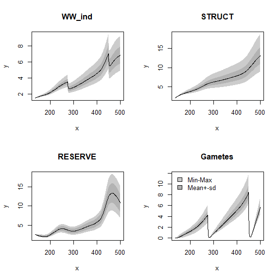

```r
sensrun_sinop <-function(pars, outtimes)
{
  P <- mussel_run_debind(parms = pars, yini = Sinop_INI,
                         times = Sinop_times,
                         f_Phyto = Sinop_phyc ,
                         f_Temp = Sinop_temp,
                         f_Detritus = Sinop_DtC,
                         f_O2 = sinop_o2_f,
                         f_Sim = Sinop_SIM)
  return(as.data.frame(P))
}
SENS_SINOP <- sensRange(func = sensrun_sinop, parms = pars, dist = "unif",
                        parRange =SENS_RANGE, sensvar=c("Length","WW_ind","STRUCT","Gonads","Gametes","RESERVE"),
                        num=50)
Gsens_SINOP<-summary(SENS_SINOP)
plot(Gsens_SINOP,which = c("WW_ind","STRUCT","RESERVE","Gametes"))
```

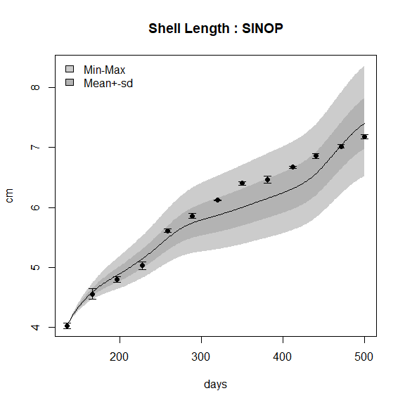

```r
# SINOP LENGTH PLOT

plot(Gsens_SINOP,which = c("Length"),
     ylab = c("cm"),
     xlab = c("days"),
     main = c("Shell Length : SINOP"))
points(x = Sinop_data$day , y = Sinop_data$length_mean, pch = 19, cex = 1)
arrows(Sinop_data$day, Sinop_data$length_upper,
       Sinop_data$day, Sinop_data$length_lower,
       length=0.05, angle=90, code=3)
```

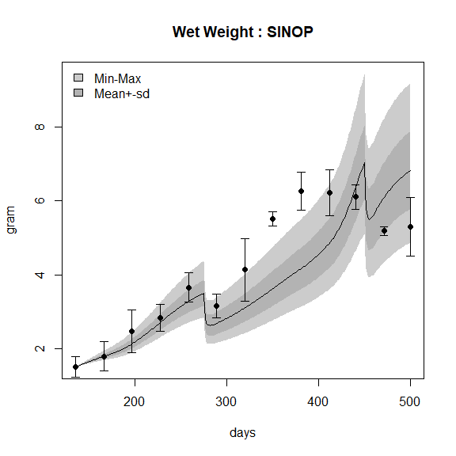

```r
# SINOP WW PLOT

plot(Gsens_SINOP,which = c("WW_ind"),
     ylab = c("gram"),
     xlab = c("days"),
     main = c("Wet Weight : SINOP"))

points(x = Sinop_data$day , y = Sinop_data$WW_mean, pch = 19, cex = 1)
arrows(Sinop_data$day, Sinop_data$WW_upper,
       Sinop_data$day, Sinop_data$WW_lower,
       length=0.05, angle=90, code=3)
```

### sensitivity at Marmara Sea

Both the Length and biomass data were used for calibration of the model  
*Growth and survival performances of Mediterranean mussel (Mytilus galloprovincialis, Lamarck, 1819) on different depths in Cardak lagoon, Dardanelles.*  
Vural et al., 2015

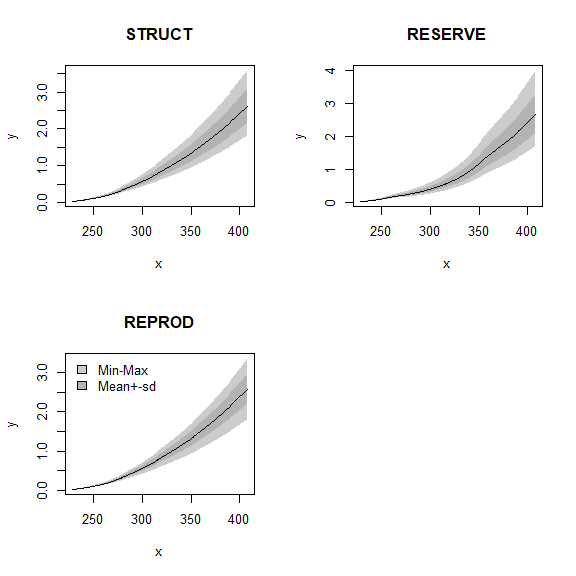

```r
sensrun_marmara <-function(pars, outtimes)
{
  P <- mussel_run_debind(parms = pars, yini = Marm_INI,
                         times = Marm_times,
                         f_Phyto = Marm_phyc ,
                         f_Temp = Marm_temp,
                         f_Detritus = Marm_DtC,
                         f_Sim = Marm_SIM,
                         f_O2 = Marm_o2_f)
  return(as.data.frame(P))
}
SENS_MARM <- sensRange(func = sensrun_marmara, parms = pars, dist = "unif",
                       parRange =SENS_RANGE, sensvar=c("STRUCT","RESERVE","REPROD","Length","WW_ind"),
                       num=50)
Gsens_MARM<-summary(SENS_MARM)
plot(Gsens_MARM,which = c("STRUCT","RESERVE","REPROD"))
# Marmara Length
plot(Gsens_MARM,which = c("Length"),
     ylab = c("cm shell"),
     xlab = c("days"))
```

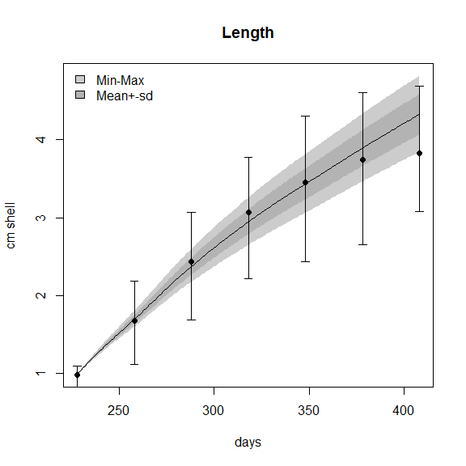

```r
points(x = Marm_data$day , y = Marm_data$length.mm/10, pch = 19, cex = 1)
arrows(Marm_data$day, Marm_data$length.mm.min/10,
       Marm_data$day, Marm_data$length.mm.max/10,
       length=0.05, angle=90, code=3)
```

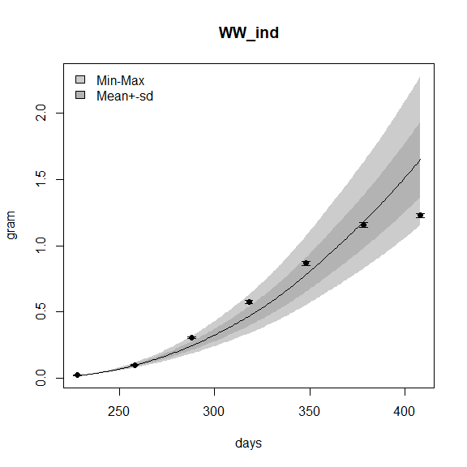

```r
# plot marmara weight
plot(Gsens_MARM,which = c("WW_ind"),
     ylab = c("gram"),
     xlab = c("days"))
points(x = Marm_data$day , y = Marm_data$ww_g_est, pch = 19, cex = 1)
arrows(Marm_data$day, Marm_data$ww_g_est - Marm_data$ww_g_est_sd,
       Marm_data$day, Marm_data$ww_g_est + Marm_data$ww_g_est_sd,
       length=0.05, angle=90, code=3)
```

### Validation & Sensitivity of growth curves at Sevastopol bay (Crimea)

These data are only used for validation of the individual growth model  
*Individual variability of growth of the cultivated Mytilus galloprovincialis Lam. in various habitat conditions of the Black sea coastal zone*  
Chelyadina & Popov, 2020

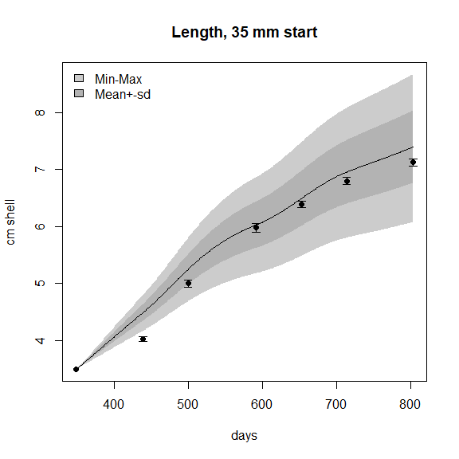

```r
sensrun_Crim35 <-function(pars, outtimes)
{
  P <- mussel_run_debind(parms = pars, yini = Crim_INI_35,
                         times = Crim_times,
                         f_Phyto = Crim_phyc,
                         f_Temp = Crim_temp,
                         f_Detritus = Crim_DtC,
                         f_O2 = Crim_o2_f,
                         f_Sim = Crim_SIM)
  return(as.data.frame(P))
}

SENS_CRIM35 <- sensRange(func = sensrun_Crim35, parms = pars, dist = "unif",
                         parRange =SENS_RANGE, sensvar=c("STRUCT","RESERVE","REPROD","Length","WW_ind"),
                         num=50)
Gsens_CRIM35<-summary(SENS_CRIM35)
plot(Gsens_CRIM35,which = c("Length"),
     ylab = "cm shell", xlab = "days", main = "Length, 35 mm start")
points(x = Crimea_data$times , y = Crimea_data$ini_35_size, pch = 19, cex = 1)
arrows(Crimea_data$times, Crimea_data$ini_35_size - Crimea_data$ini_35_sd,
       Crimea_data$times, Crimea_data$ini_35_size + Crimea_data$ini_35_sd,
       length=0.05, angle=90, code=3)
```

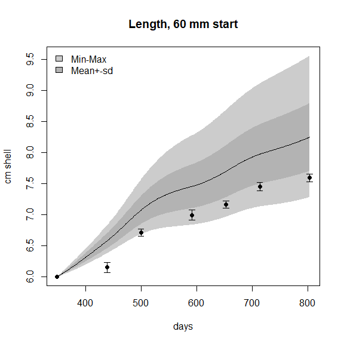

```r
# dataset 2 mussel growing from 60mm
sensrun_Crim60 <-function(pars, outtimes)
{
  P <- mussel_run_debind(parms = pars, yini = Crim_INI_60,
                         times = Crim_times,
                         f_Phyto = Crim_phyc ,
                         f_Temp = Crim_temp,
                         f_Detritus = Crim_DtC,
                         f_O2 = Crim_o2_f,
                         f_Sim = Crim_SIM)
  return(as.data.frame(P))
}
# run sensitivity Crim 35
SENS_CRIM60 <- sensRange(func = sensrun_Crim60, parms = pars, dist = "unif",
                         parRange =SENS_RANGE, sensvar=c("STRUCT","RESERVE","REPROD","Length","WW_ind"),
                         num=50)
Gsens_CRIM60<-summary(SENS_CRIM60)
plot(Gsens_CRIM60,which = c("Length"),
     ylab = "cm shell", xlab = "days", main = "Length, 60 mm start")
points(x = Crimea_data$times , y = Crimea_data$ini_60_size, pch = 19, cex = 1)
arrows(Crimea_data$times, Crimea_data$ini_60_size - Crimea_data$ini_60_sd,
       Crimea_data$times, Crimea_data$ini_60_size + Crimea_data$ini_60_sd,
       length=0.05, angle=90, code=3)
```

### Physiological rates of *Mytilus galloprovincialis* at Alfacs Bay (Spain)

*Feeding behavior of the mussel Mytilus galloprovincialis (L.) in a Mediterranean estuary: A field study*  
Galimany et al., 2011

```r
RATES.FIT <- data.frame(index = NA, Clear = NA, OrgFilt = NA,Reject = NA, OrgIng = NA, Assim = NA)
RATES.low <- data.frame(index = NA, Clear = NA, OrgFilt = NA,Reject = NA, OrgIng = NA, Assim = NA)
RATES.high <- data.frame(index = NA, Clear = NA, OrgFilt = NA,Reject = NA, OrgIng = NA, Assim = NA)
for(i in 1:nrow(Feeding_data)){



  F_INI = get_INI_indiv(Length = Feeding_data$Length[i])

  fphy = cbind(1:2, rep(Feeding_data$PhyC[i],2))
  ftemp = cbind(1:2, rep(Feeding_data$Temp[i],2))
  fsim = cbind(1:2, rep(Feeding_data$SIM[i],2))
  fdet =   cbind(1:2, rep(Feeding_data$DT[i],2))

  OUT= mussel_run_debind(times = 1:2,
                         yini = F_INI,
                         f_Phyto = fphy,
                         f_Temp = ftemp,
                         f_Sim = fsim,
                         f_Detritus = fdet,
                         parms = pars)


  minvals= SENS_RANGE$min
  names(minvals)<- rownames(SENS_RANGE)
  maxvals= SENS_RANGE$max
  names(maxvals)<- rownames(SENS_RANGE)

  fitP_low <- pars
  fitP_low[names(minvals)] <- minvals
  fitP_high <- pars
  fitP_high[names(maxvals)] <- maxvals

  OUT_h= mussel_run_debind(times = 1:2,
                           yini = F_INI,
                           f_Phyto = fphy,
                           f_Temp = ftemp,
                           f_Sim = fsim,
                           f_Detritus = fdet,
                           parms = fitP_high)



  OUT_l= mussel_run_debind(times = 1:2,
                           yini = F_INI,
                           f_Phyto = fphy,
                           f_Temp = ftemp,
                           f_Sim = fsim,
                           f_Detritus = fdet,
                           parms = fitP_low)




  # need specific unit transformations to compare with dataset

  outdf = as.data.frame(OUT)
  outdf_h = as.data.frame(OUT_h)
  outdf_l = as.data.frame(OUT_l)


  RATES.FIT[i,]<- c(i,
                    outdf$Clearance_rate[1], #[clearance rate m3/d -> l/h]
                    outdf$Filtration_C[1],
                    outdf$Pseudofaeces_C[1]/(0.001+outdf$Filtration_C[1])*100,# % of filtred C rejected
                    outdf$Ingestion[1],
                    outdf$Assimilation[1]/pars["aeff"])

  RATES.high[i,]<- c(i,
                     outdf_h$Clearance_rate[1], #[clearance rate m3/d -> l/h]
                     outdf_h$Filtration_C[1],
                     outdf_h$Pseudofaeces_C[1]/(0.001+outdf_h$Filtration_C[1])*100,# % of filtred C rejected
                     outdf_h$Ingestion[1],
                     outdf_h$Assimilation[1]/fitP_high["aeff"])

  RATES.low[i,]<- c(i,
                    outdf_l$Clearance_rate[1], #[clearance rate m3/d -> l/h]
                    outdf_l$Filtration_C[1],
                    outdf_l$Pseudofaeces_C[1]/(0.001+outdf_l$Filtration_C[1])*100,# % of filtred C rejected
                    outdf_l$Ingestion[1],
                    outdf_l$Assimilation[1]/fitP_low["aeff"])
}

RATES.FIT <- na.omit(RATES.FIT)
RATES.high <- na.omit(RATES.high)
RATES.low <- na.omit(RATES.low)
```

### plots of physiological rates, data are used for inital calibration

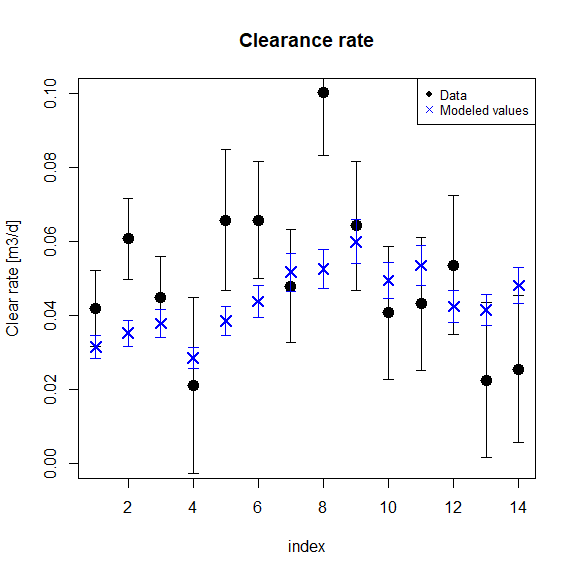

```r
# plot for clearance rate
plot(x = Feeding_data$index, y = Feeding_data$Clear, ylim = c(0,0.1), cex = 1.5, lwd = 2,pch = 19,
     xlab = "index", ylab = "Clear rate [m3/d]",main = "Clearance rate")
arrows(Feeding_data$index, Feeding_data$Clear + Feeding_data$Clear_sd*2,
       Feeding_data$index, Feeding_data$Clear - Feeding_data$Clear_sd*2,
       length=0.05, angle=90, code=3)

points(x = RATES.FIT$index, y = RATES.FIT$Clear, col = "blue", pch = 4,cex = 1.5, lwd = 2)
arrows(RATES.FIT$index, RATES.low$Clear,
       RATES.FIT$index, RATES.high$Clear,
       length=0.05, angle=90, code=3, col = "blue")



legend("topright", pch = c(19,4), col = c("black","blue"), cex = 0.8,
       legend = c("Data","Modeled values"))
```

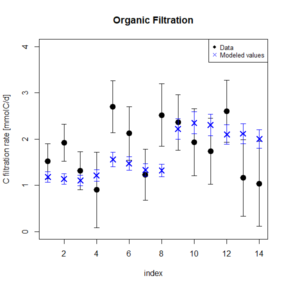

```r
# plot for filtration rate
plot(x = Feeding_data$index, y = Feeding_data$OrgFilt, ylim = c(0,4), cex = 1.5, lwd = 2,pch = 19,
     xlab = "index", ylab = "C filtration rate [mmolC/d]",main = "Organic Filtration")
arrows(Feeding_data$index, Feeding_data$OrgFilt + Feeding_data$OrgFilt_sd*2,
       Feeding_data$index, Feeding_data$OrgFilt - Feeding_data$OrgFilt_sd*2,
       length=0.05, angle=90, code=3)

points(x = RATES.FIT$index, y = RATES.FIT$OrgFilt, col = "blue", pch = 4,cex = 1.5, lwd = 2)
arrows(RATES.FIT$index, RATES.low$OrgFilt,
       RATES.FIT$index, RATES.high$OrgFilt,
       length=0.05, angle=90, code=3, col = "blue")
legend("topright", pch = c(19,4), col = c("black","blue"), cex = 0.8,
       legend = c("Data","Modeled values"))
```

```r
## REJECTION
#  plot(x = Feeding_data$index, y = Feeding_data$Reject, ylim = c(0,50), cex = 1.5, lwd = 2,pch = 19,
#       xlab = "index", ylab = "Rejection [%]",main = "Rejection")
#  points(x = Feeding_data$index, y = Feeding_data$Reject + Feeding_data$Reject_sd)
#  points(x = Feeding_data$index, y = Feeding_data$Reject - Feeding_data$Reject_sd)

#  points(x = default.run$index, y = default.run$Reject, col = "red", pch = 2,cex = 1.5, lwd = 2)
#  points(x = FIT.run$index, y = FIT.run$Reject, col = "blue", pch = 3,cex = 1.5, lwd = 2)
#  legend("topright", pch = c(19,2,3), col = c("black","red","blue"), cex = 0.8,
#         legend = c("DATA","MOD_Guess","MOD_FIT"))
```

### Optional addition (this is where the model diverges most from the data)

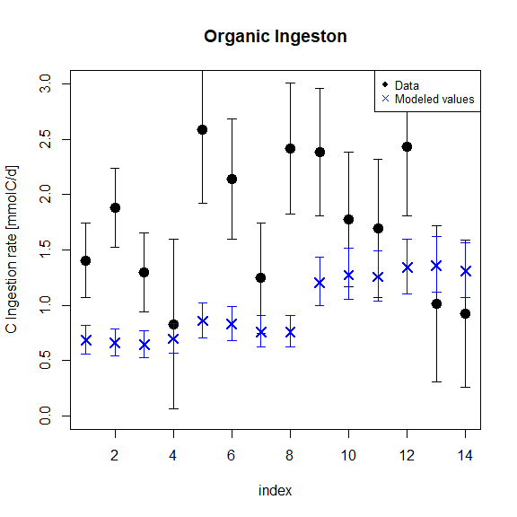

```r
#
plot(x = Feeding_data$index, y = Feeding_data$OrgIng, ylim = c(0,3), cex = 1.5, lwd = 2,pch = 19,
     xlab = "index", ylab = "C Ingestion rate [mmolC/d]",main = "Organic Ingeston")
arrows(Feeding_data$index, Feeding_data$OrgIng + Feeding_data$OrgIng_sd*2,
       Feeding_data$index, Feeding_data$OrgIng - Feeding_data$OrgIng_sd*2,
       length=0.05, angle=90, code=3)


points(x = RATES.FIT$index, y = RATES.FIT$OrgIng, col = "blue", pch = 4,cex = 1.5, lwd = 2)
arrows(RATES.FIT$index, RATES.low$OrgIng,
       RATES.FIT$index, RATES.high$OrgIng,
       length=0.05, angle=90, code=3, col = "blue")
legend("topright", pch = c(19,4), col = c("black","blue"), cex = 0.8,
      legend = c("Data","Modeled values"))
```

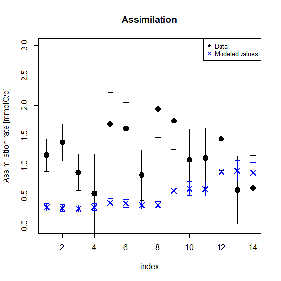

```r
#
plot(x = Feeding_data$index, y = Feeding_data$Assim, ylim = c(0,3), cex = 1.5, lwd = 2,pch = 19,
     xlab = "index", ylab = "Assimilation rate [mmolC/d]",main = "Assimilation")
arrows(Feeding_data$index, Feeding_data$Assim + Feeding_data$Assim_sd*2,
       Feeding_data$index, Feeding_data$Assim - Feeding_data$Assim_sd*2,
       length=0.05, angle=90, code=3)

# ! /aeff because feeding respiration is not counted into assimilation in model
points(x = RATES.FIT$index, y = (RATES.FIT$Assim/pars["aeff"]), col = "blue", pch = 4,cex = 1.5, lwd = 2)
arrows(RATES.FIT$index, RATES.low$Assim/pars["aeff"],
       RATES.FIT$index, RATES.high$Assim/pars["aeff"],
       length=0.05, angle=90, code=3, col = "blue")
legend("topright", pch = c(19,4), col = c("black","blue"), cex = 0.8,
       legend = c("Data","Modeled values"))
```